# Travel Package Purchase Prediction Project

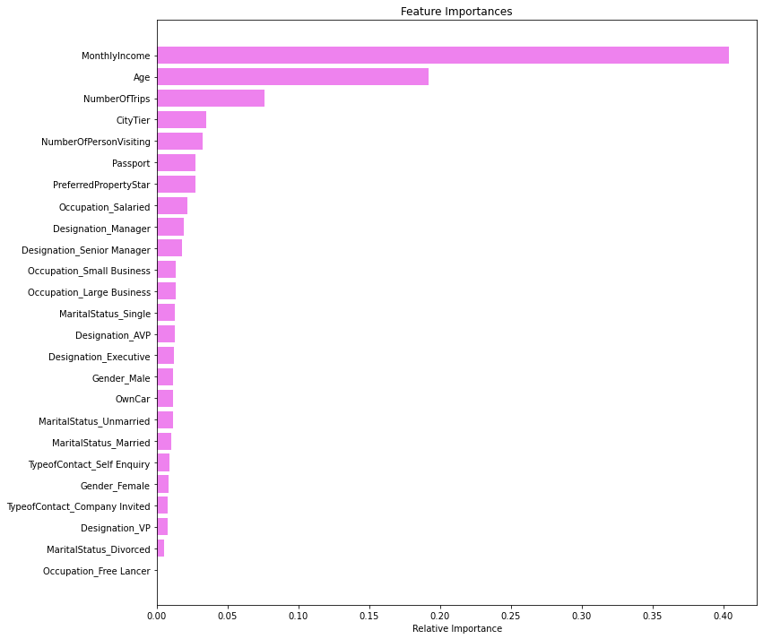

```python
feature_names = X_train.columns
importances = abc_tuned.feature_importances_
indices = np.argsort(importances)

plt.figure(figsize=(12, 12))
plt.title("Feature Importances")
plt.barh(range(len(indices)), importances[indices], color="violet", align="center")
plt.yticks(range(len(indices)), [feature_names[i] for i in indices])
plt.xlabel("Relative Importance")
plt.show()
```

### Conclusions after Analysis of Bagging and Boosting Models

- Both Bagging and Boosting Models , gave almost similar outcomes, thus increasing the confidence levels of this exercise
- Tuned Models of Random Forest and Adaptive Boost provided better Recall values
- Monthly Income, Age and NumberofTrips are commonly identified as the important features
- Other features like CityTier, Passport, NumberofPersonVisiting can also be considered as important

### Business Insights for Marketing team

- Marketing Campaigns for the current/future products should target customers with higher MonthlyIncome, Age and NumberofTrips (in the order)
- The selective campaigns for a new Wellness Package, is significantly important to people in the middle Age. (Our model analysis emphasizes that the Age group of (example 50 plus) is an important segment to focus on
- NumberOfTrips denotes, prior travel patterns, so people have already enough travelled are prone to buy new and unique travel packages.
- Customers who already have a passport is a favorable segment, as they already intent to travel internationally. This same segment of people may also be inclined to travel domestic as well.
- Higher NumberOfPersonVisiting, also implies family or group travellers, the company can cater special travel plans to this groups
- Preferred Property Star is also an important factor, which implies customers are preferring higher segment of hotel stays / resorts / travel segments.